# Les vaches, les amphibiens et vous

2023-04-25

## Contexte

Choix de projet = Effets des pâturages sur l’abondance et la diversité des amphibiens.

Invertebrés vs sensibilité / eutrophisation Écrevisses vs sensibilité / eutrophisation Poisson ??

## Objectif et question de recherche (étape 1)

Vérifier l’impact du pâturage par le bétail (vaches) sur les communautés d’amphibiens.

## Hypothèses et prédictions (étape 2)

La présence et l’intensité d’M’utilisation du bétail modifient les conditions physico-chimiques des étangs, et ainsi l’abondance des invertébrés, poissons et écrevisses, ce qui détermine la composition des communautés amphibiennes.

Prédictions: - Les conditions physico-chimiques sont différentes entre les étangs cloturés vs non-cloturés. - Les vaches seront corrélées positivement aux nitrites - Les vaches seront corrélées positivement à la *temperature*? - Les vaches seront corrélées positivement à la conductivité - Les vaches seront corrélées négativement au pH - Les vaches seront corrélées négativement à l’O^2

## Variables du système (étape 3)

- Modèle conceptuel? Voici le jeu de données :

```
## Rows: 40
## Columns: 22
## $ etang        <fct> 131, 151, 55, 134, 603, 41, 135, 126, 154, 583, 557, 16, …
## $ cloture      <fct> No, No, No, No, No, No, No, Yes, No, No, No, No, No, Yes,…
## $ vache_std    <dbl> 0.2581989, 0.5345225, 0.1936492, 0.2415229, 0.4183300, 0.…
## $ profondeur   <int> 220, 330, 88, 460, 285, 188, 130, 513, 690, 230, 180, 330…
## $ conductivite <dbl> 5.099866, 5.543222, 5.240688, 5.136974, 5.070789, 3.98527…
## $ nitrates     <dbl> 2.135349, 2.919391, 2.253395, 2.646175, 2.351375, 1.62924…
## $ oxygene      <dbl> 2.6878475, 1.5686159, 4.1850989, 2.1747517, 3.2580965, 3.…
## $ pH           <dbl> 4.70, 3.52, 3.22, 3.93, 10.02, 11.56, 6.83, 4.06, 4.61, 4…
## $ temperature  <dbl> 25.3, 24.3, 34.0, 26.9, 28.9, 32.6, 26.4, 24.2, 27.6, 25.…
## $ aire         <dbl> 5.657663, 5.965964, 6.233027, 7.043957, 7.043957, 7.35225…
## $ invertebres  <dbl> 0.8738314, 0.5912750, 0.2691703, 0.5331832, 0.9235003, 1.…
## $ ecrevisses   <dbl> 0.0000000, 0.9867057, 2.1670829, 0.5142743, 1.1499524, 0.…
## $ poissons     <dbl> 0.7270781, 0.6869708, 0.7989655, 1.7655102, 0.0000000, 0.…
## $ A_Gr         <dbl> 0.0000000, 0.0000000, 0.0000000, 0.0000000, 0.0000000, 0.…
## $ G_Ca         <dbl> 0.00000000, 0.00000000, 0.00000000, 0.00000000, 0.0222306…
## $ S_La         <dbl> 0.10762875, 0.00000000, 0.00000000, 0.09443231, 0.0000000…
## $ H_Ci         <dbl> 0.00000000, 0.00000000, 0.00000000, 0.00000000, 0.0000000…
## $ H_Fe         <dbl> 0.0000000, 0.0000000, 0.0000000, 0.0000000, 0.0000000, 0.…
## $ H_Sq         <dbl> 0.000000000, 0.000000000, 0.006617525, 0.000000000, 0.190…
## $ L_Gr         <dbl> 0.11205372, 0.00000000, 0.00000000, 0.00000000, 0.0000000…
## $ L_Sp         <dbl> 0.00000000, 0.04558664, 0.00000000, 0.03452805, 0.0000000…
## $ N_Vi         <dbl> 0.0000000, 0.0000000, 0.0000000, 0.0000000, 0.0000000, 0.…
```

```
##      etang    cloture    vache_std        profondeur     conductivite
##  102    : 1   No :35   Min.   :0.0000   Min.   : 88.0   Min.   :3.985
##  114    : 1   Yes: 5   1st Qu.:0.1241   1st Qu.:190.0   1st Qu.:4.948
##  122    : 1            Median :0.2035   Median :302.5   Median :5.174
##  126    : 1            Mean   :0.2130   Mean   :314.3   Mean   :5.199
##  130    : 1            3rd Qu.:0.2972   3rd Qu.:450.0   3rd Qu.:5.509
##  131    : 1            Max.   :0.5758   Max.   :690.0   Max.   :6.635
##  (Other):34
##     nitrates        oxygene             pH          temperature
##  Min.   :1.552   Min.   :-1.204   Min.   : 1.380   Min.   :23.80
##  1st Qu.:1.962   1st Qu.: 1.099   1st Qu.: 4.027   1st Qu.:24.38
##  Median :2.249   Median : 1.995   Median : 5.305   Median :26.10
##  Mean   :2.384   Mean   : 1.970   Mean   : 6.059   Mean   :26.36
##  3rd Qu.:2.730   3rd Qu.: 2.601   3rd Qu.: 7.590   3rd Qu.:27.52
##  Max.   :3.590   Max.   : 4.185   Max.   :11.880   Max.   :34.00
##
##       aire        invertebres       ecrevisses        poissons
##  Min.   :5.658   Min.   :0.2166   Min.   :0.0000   Min.   :0.0000
##  1st Qu.:7.587   1st Qu.:0.6074   1st Qu.:0.0000   1st Qu.:0.1383
##  Median :8.210   Median :0.8376   Median :0.4537   Median :0.7630
##  Mean   :8.160   Mean   :0.8428   Mean   :0.6984   Mean   :0.7179
##  3rd Qu.:8.739   3rd Qu.:1.0636   3rd Qu.:1.1522   3rd Qu.:1.0389
##  Max.   :9.817   Max.   :1.7122   Max.   :2.5517   Max.   :1.8759
##
##       A_Gr             G_Ca              S_La              H_Ci
##  Min.   :0.0000   Min.   :0.00000   Min.   :0.00000   Min.   :0.00000
##  1st Qu.:0.0000   1st Qu.:0.00000   1st Qu.:0.00000   1st Qu.:0.00000
##  Median :0.0000   Median :0.00000   Median :0.00000   Median :0.00000
##  Mean   :0.0250   Mean   :0.02500   Mean   :0.02500   Mean   :0.02500
##  3rd Qu.:0.0000   3rd Qu.:0.02232   3rd Qu.:0.04166   3rd Qu.:0.03357
##  Max.   :0.4613   Max.   :0.31564   Max.   :0.19490   Max.   :0.15887
##
##       H_Fe             H_Sq               L_Gr              L_Sp
##  Min.   :0.0000   Min.   :0.000000   Min.   :0.00000   Min.   :0.00000
##  1st Qu.:0.0000   1st Qu.:0.000000   1st Qu.:0.00000   1st Qu.:0.00000
##  Median :0.0000   Median :0.001653   Median :0.00000   Median :0.00000
##  Mean   :0.0250   Mean   :0.025000   Mean   :0.02500   Mean   :0.02500
##  3rd Qu.:0.0000   3rd Qu.:0.016615   3rd Qu.:0.04348   3rd Qu.:0.03056
##  Max.   :0.7735   Max.   :0.190314   Max.   :0.17084   Max.   :0.28230
##
##       N_Vi
##  Min.   :0.0000
##  1st Qu.:0.0000
##  Median :0.0000
##  Mean   :0.0250
##  3rd Qu.:0.0000
##  Max.   :0.8608
##
```

## Rôle, type et distribution des variables (étape 4)

Jettons un coup d’oeil premièrement à la variable dépendante, représentée par une matrice d’abondance de la communauté amphibienne. Les colonnes représentent les espèces, et les lignes représentent les sites.

```r
amphi<-dat %>%
  select(etang,A_Gr:N_Vi) %>%
  column_to_rownames("etang")
# Étendue
range(amphi)
```

```
## [1] 0.0000000 0.8607952
```

```r
# Nombre de zéros, puis proportion de zéros dans la communauté
sum(amphi==0) ; sum(amphi==0)/(nrow(amphi)*ncol(amphi))
```

```
## [1] 254
```

```
## [1] 0.7055556
```

Les valeurs d’abondance relative sont entre 0 et 0.86. Les zéros (absences) composent 70.5% de la matrice. Les données d’abondance ont été standardisées par unité d’effort et par abondance totale pour chaque espèce.

## Étape 4 - distribution des Ys

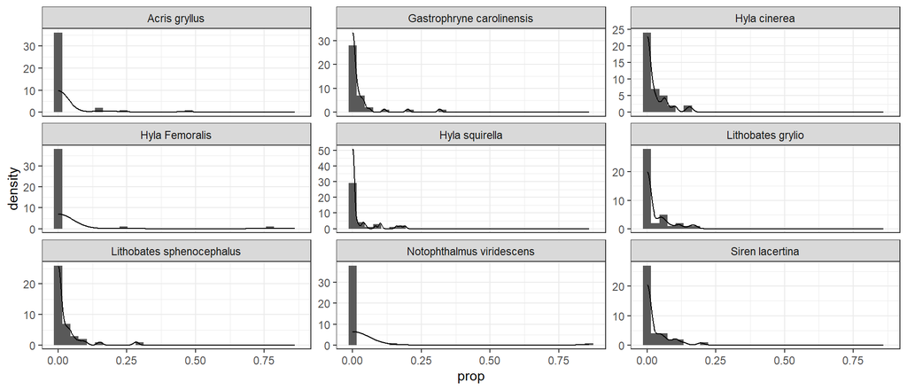

## Étape 4 - Variables indépendantes X

La variable indépendante “cloture” est une variable catégorique à 2 facteurs (Yes, No). La variable “Intensité d’utilisation de l’étang par le bétail” est une variable numérique continue dont la distribution [min ; max = 0 ; 0.6] est biaisée à gauche.

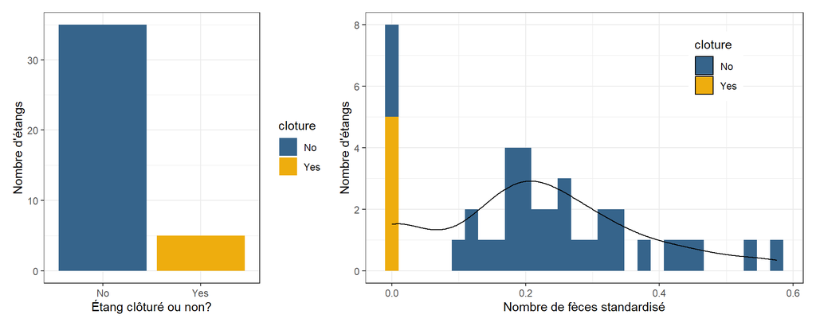

5 étangs sont clôturés, 35 étangs ne l’étaient pas. Parmi les étangs non-cloturés, 3 étangs ne semblent pas avoir été utilisés par les vaches (pas de fèces)

## Étape 4 - Covariables

### Caractéristiques physico-chimiques -> non-standardisées

- Conductivité: numérique continue, distribution normale
- Nitrates: numérique continue, distribution déviée à gauche
- Température (Celcius): numérique continue, distribution déviée à gauche
  - Quelques valeurs extrèmes

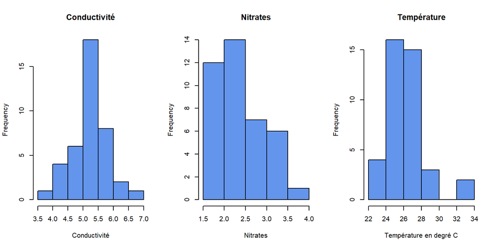

```
## [1]  1.38 11.88
```

## Étape 4 - Covariables

### Caractéristiques physico-chimiques

- Oxygène: numérique continue, distribution normale
  - Il y a des valeurs négatives!!!
- pH: numérique continue, distribution déviée à gauche
  - Des étangs sont plus acides que du jus de citron, et presqu’aussi basiques que de l’eau de Javel!

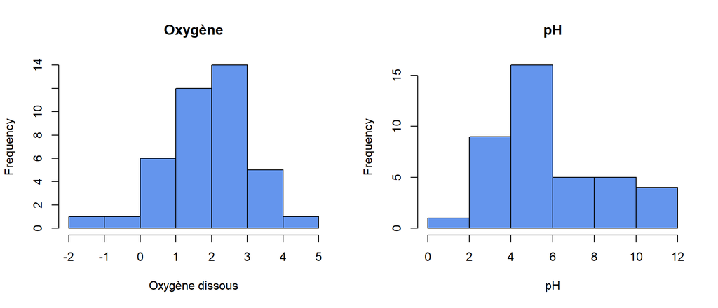

## Étape 4 - Covariables

### Caractéristiques topographiques

- Profondeur (cm): numérique continue, distribution normale
- Aire (m^2): numérique continue, distribution *relativement* normale

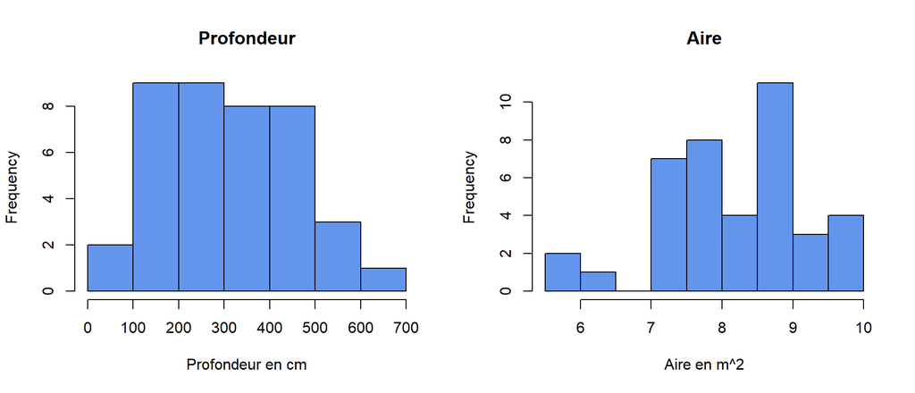

## Étape 4 - Covariables

### Facteurs biotiques

- Invertébrés: numérique continue, distribution déviée à gauche
- Écrevisses: numérique continue, distribution déviée à gauche avec beaucoup de zéros
- Poissons: numérique continue, distribution avec beaucoup de zéros

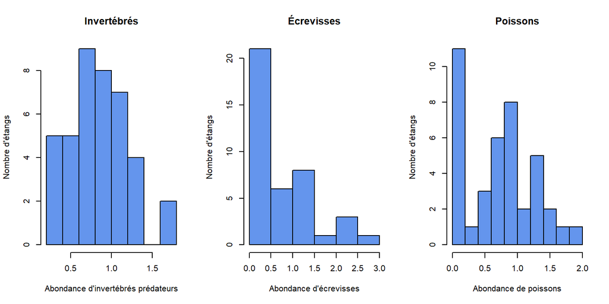

## Interactions potentielles à tester (étape 5)

Aucune. La question initiale parle plus d’objectifs specifiques en termes d’effets fixes (Clôturé. vs pas Clôturé, ou encore l’effet de l’intensité d’utilisation des vaches). On pose des questions en termes d’effets seuls - pas en interaction. On demande toutefois de prendre en compte les caractéristiques physico-chimiques et biotiques.

## Exploration des données (étape 6)

## 6.1 - Données aberrantes en X

- Les valeurs de vache_std sont entre 0 et 0.575
- Il ne semble pas y avoir de données aberrantes, mais 3 étangs non-clôturés ne semblent pas avoir été visités par les vaches.

```
## [1] 0.0000000 0.5758289
```

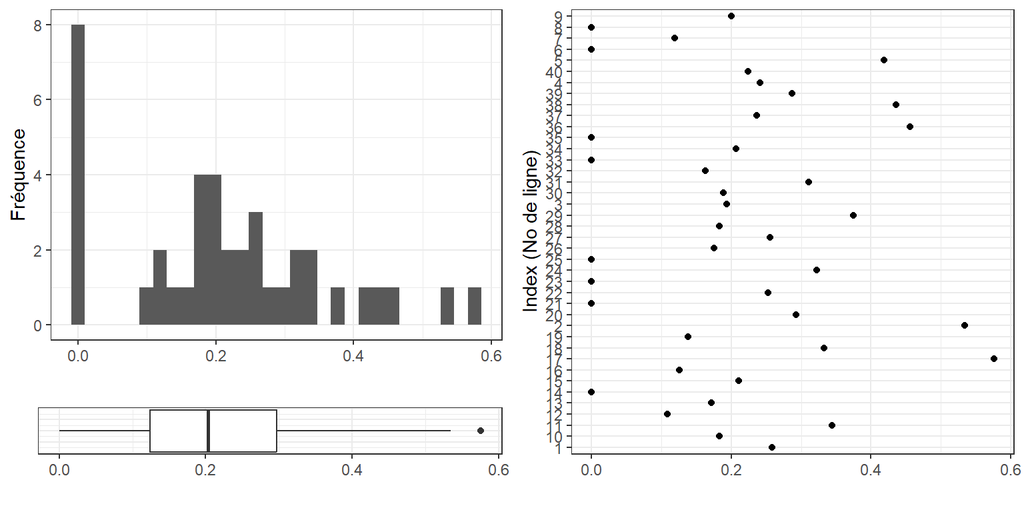

## 6.1 - Données aberrantes en X

- O2: Il y a des valeurs négatives!!!
- pH: Des étangs sont plus acides que du jus de citron, et presqu’aussi basiques que de l’eau de Javel!

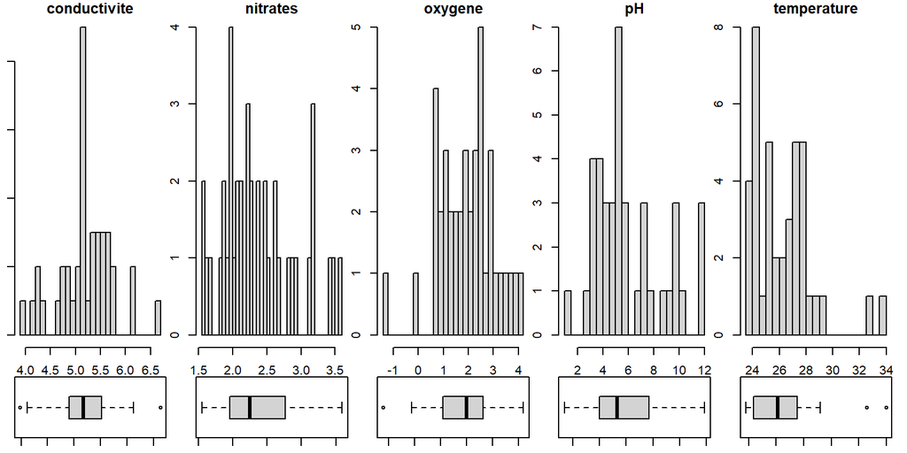

## 6.1 - Données aberrantes en X

Il ne semble pas particulièrement y avoir de données aberrantes en ce qui concerne la topographie des étangs

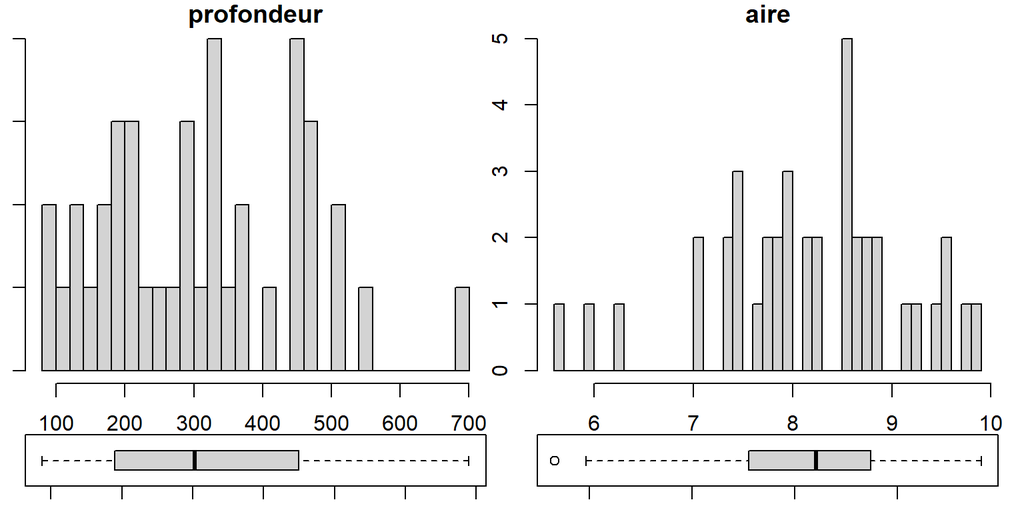

## 6.1 - Données aberrantes en X

En ce qui concerne les poissons et les écrevisses, i8l semble y avoir beaucoup de zéros. Il faudra peut-être transformer (e.g. log) les variables poissons et écrevisses. Les écrevisses étant des prédateurs des grenouilles (tétards), on pourrait peut-être travailler en absence-présence d’écrevisses dans nos analyses, si cette variable est problématique.

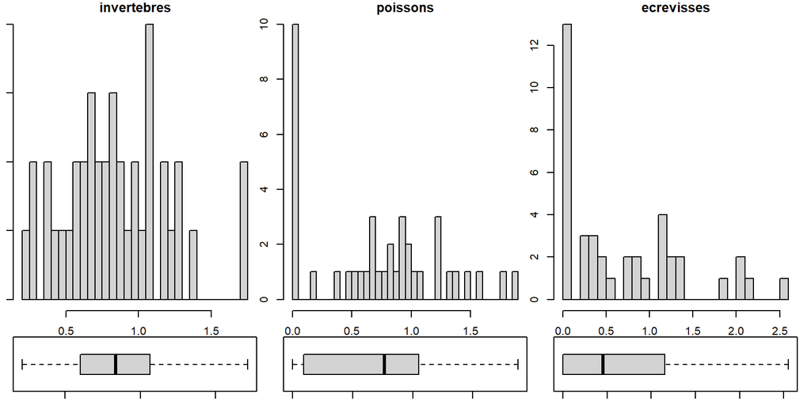

## 6.1 - Données aberrantes en Y

On a déjà jetté un coup d’oeil à la distribution des abondances relatives d’amphibien à l’étape 4. Le voici en rappel avec des boxplots.

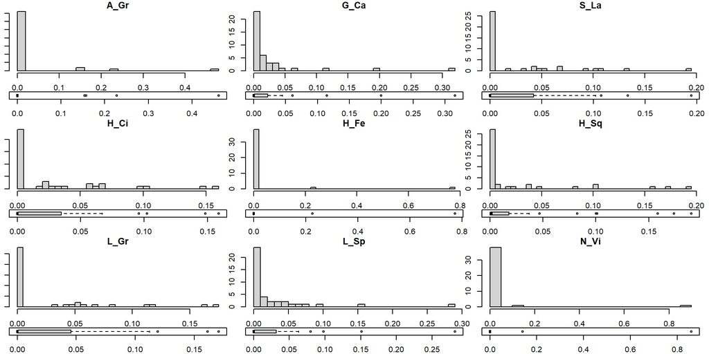

## 6.1 - Données aberrantes en Y

On peut toutefois inspecter le compte d’espèces à chaque site (convertir les abondances relatives en 0-1 pour chaque site). On peut aussi jetter un coup d’oeil à la richesse spécifique.

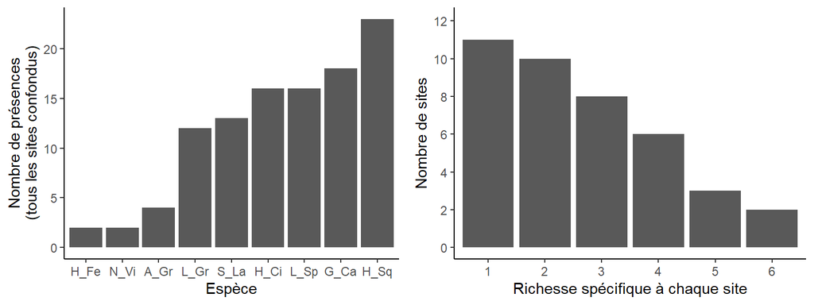

## 6.2 - Homogénéité de la variance et normalité des Ys

Dans notre cas, on ne s’attend pas à ce que la variance des Ys soit homogène (on ne fait pas des modèles linéaires où les résidus devraient être homogènes, etc.); qui plus est, ce n’est pas une supposition à respecter dans le cadre d’une analyse multivariée…

Dans notre cas, on ne s’attend pas à ce que la variance des Ys soit Normale non plus.

## 6.4 - Problèmes de 0 dans les Y

Comme on a vu plus tôt à l’étape 4 les zéros (absences) composent 70.5% de la matrice. Il se pourrait d’ailleurs que la faible présence de certaines espèces (H_Fe, N_Vi et A_GR) pose des problèmes pour l’analyse visée.

## 6.5 - Collinéarité des X

Premièrement avec les étangs non cloturés:

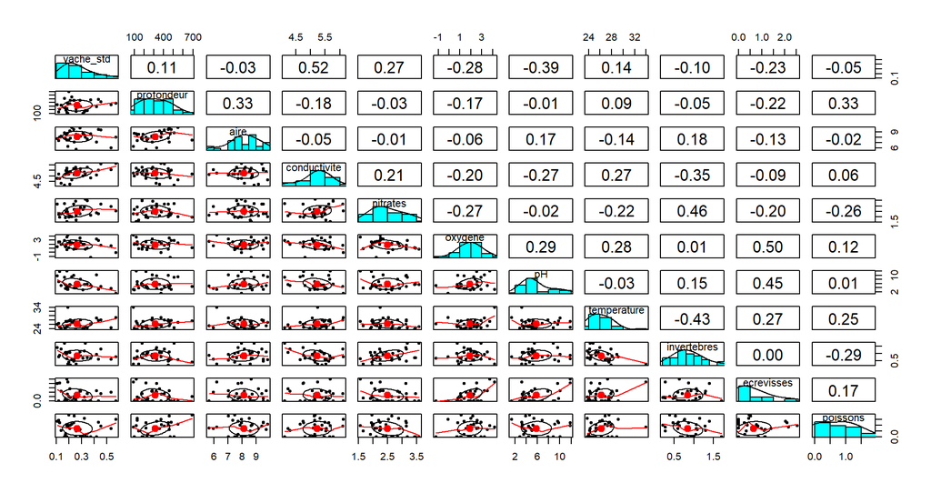

## 6.5 - Collinéarité des X

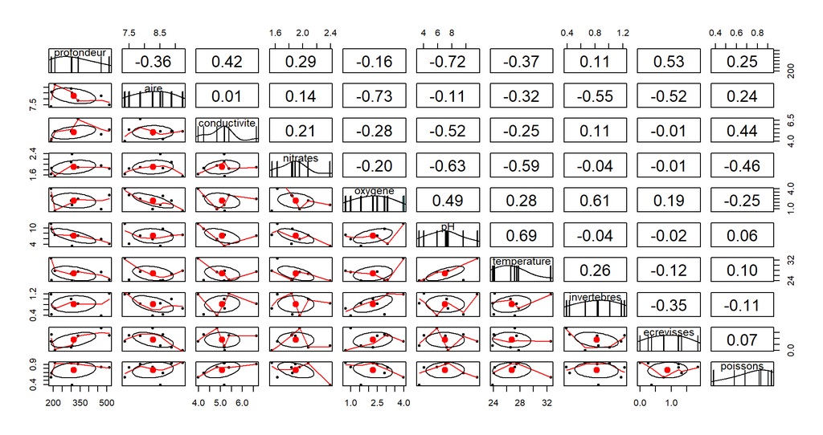

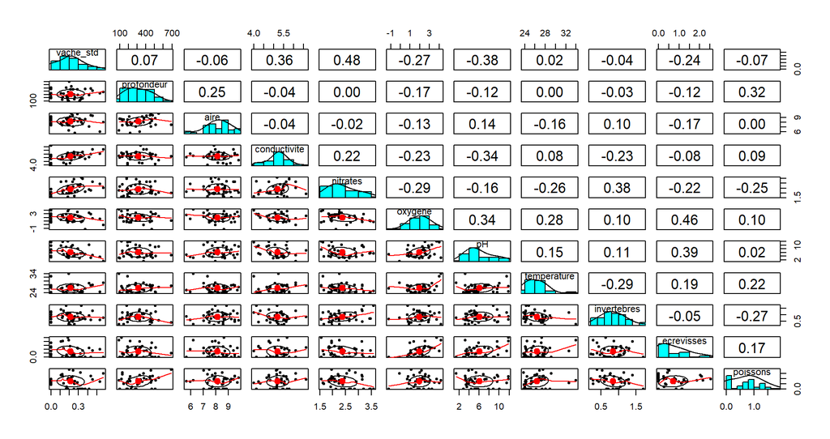

## 6.5 - Collinéarité des X

Variable cloture vs. variables *physico-chimiques*

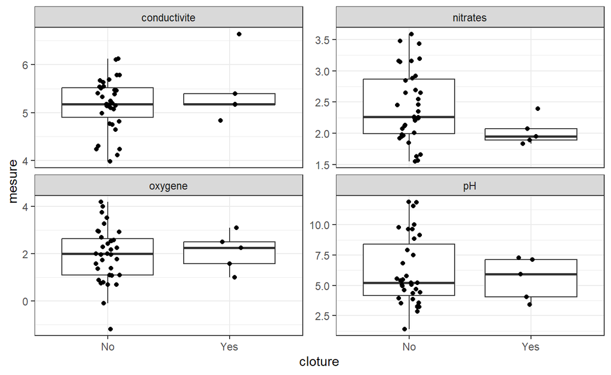

## 6.5 - Collinéarité des X

Variable cloture vs. variables *topographiques*

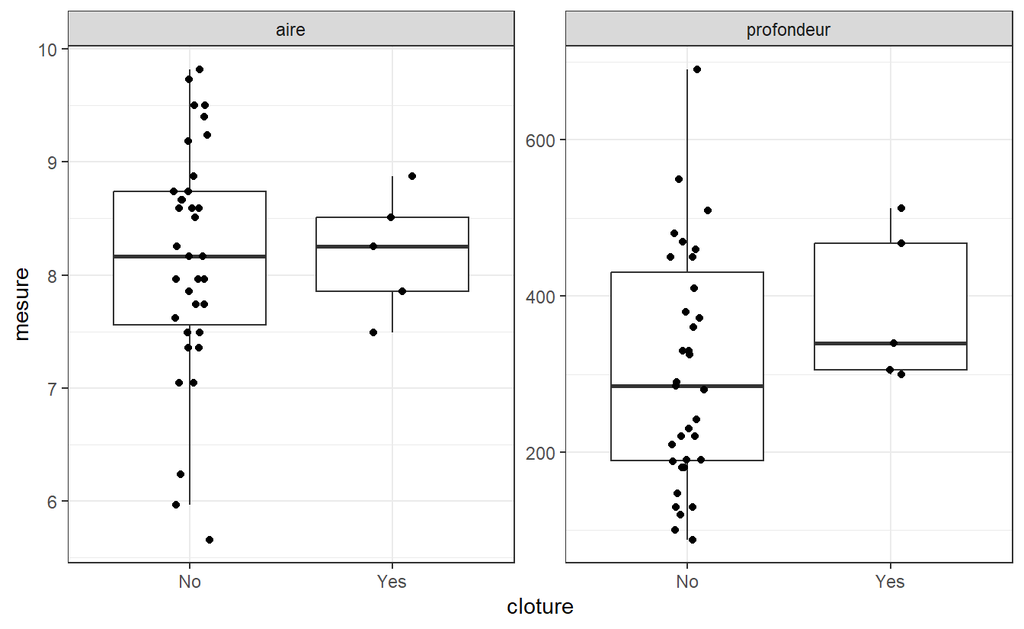

## 6.5 - Collinéarité des X

Variable clôture vs. variables *biotiques*

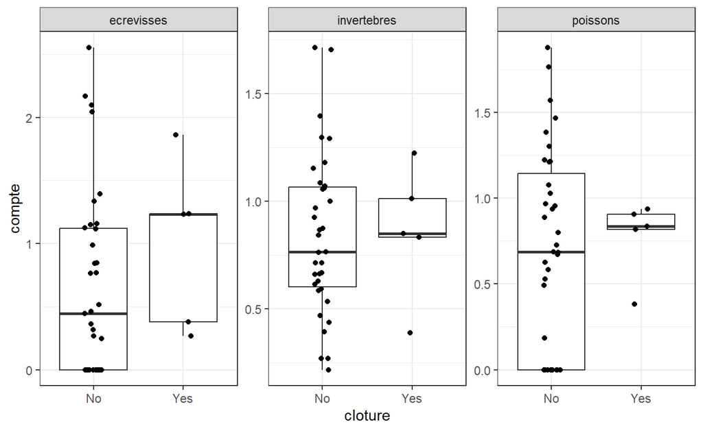

## 6.6 - Liens X et Y

Abondances relatives en fonction des paramètres physico-chimiques

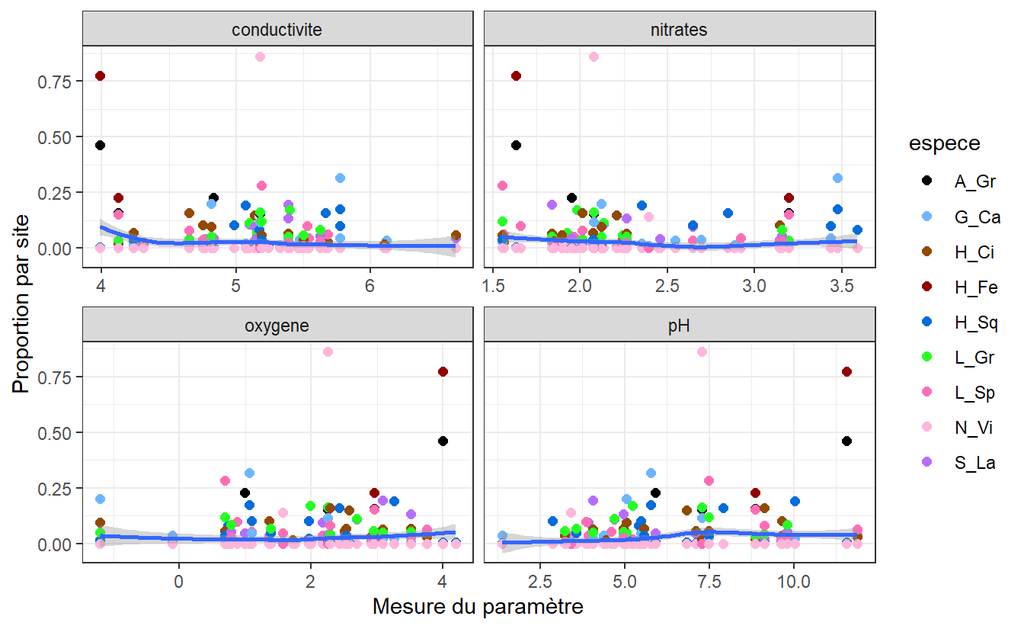

## 6.6 - Liens X et Y

Abondances relatives en fonction des caractéristiques topographiques

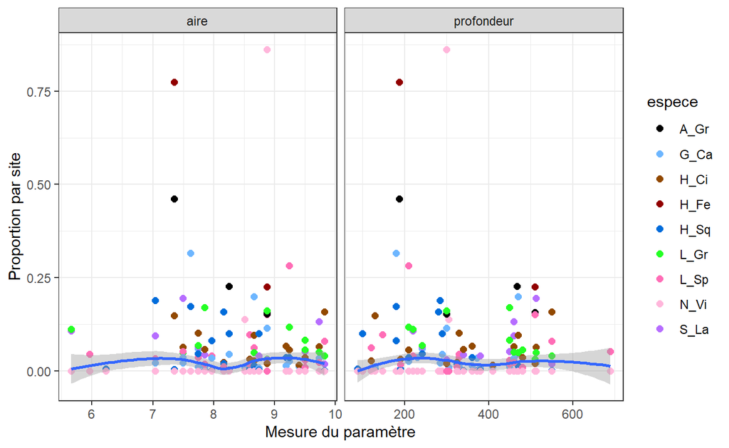

## 6.6 - Liens X et Y

Abondances relatives en fonction des facteurs biotiques

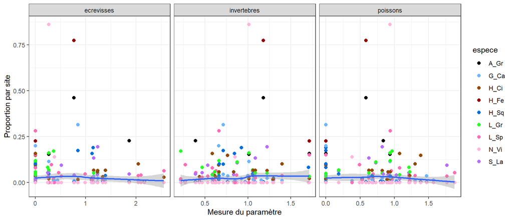

## 6.6 - Liens X et Y

Abondances relatives en fonction de l’intensité des vaches et de la présence de cloture

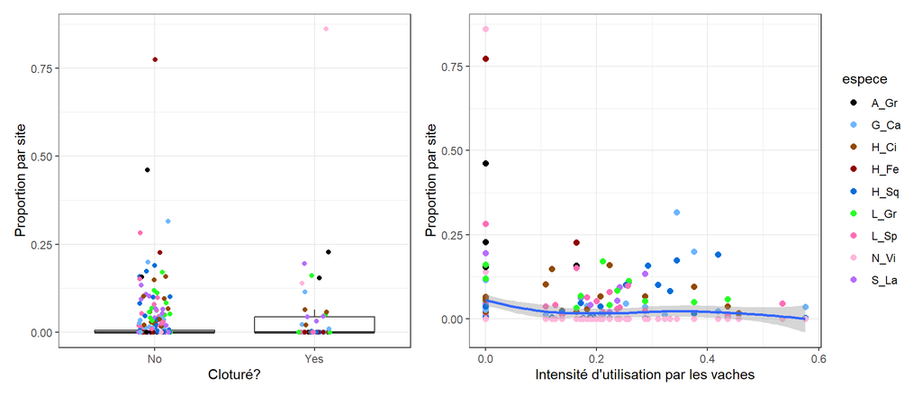

## 6.7 - Indépendance des Y

Richesse spécifique à chaque site

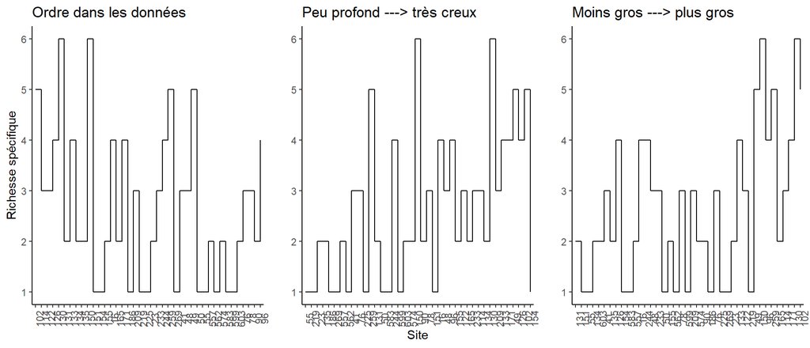

## 6.8 - Collinéarité des Y

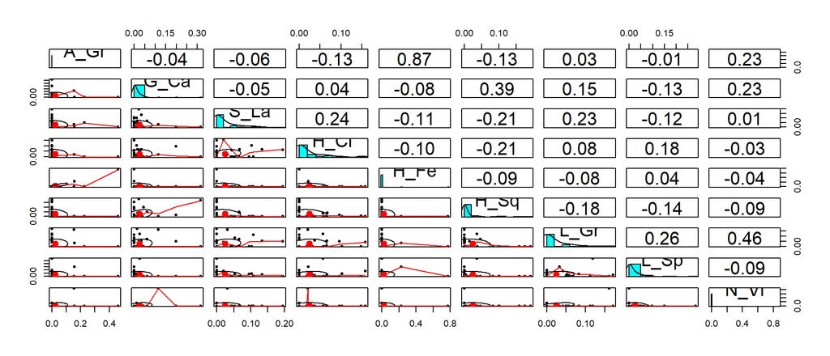

## Faits saillants de l’exploration des données (étape 6):

- Les données d’abondance ont été standardisées par unité d’effort et par abondance totale pour chaque espèce.
  - Les variables Y sont donc numériques continues vont de 0 à 0,86. La somme pour chaque espèce (colonne) est égale à 1.
  - Près de 71% des données de la matrice d’abondance sont égales à 0.
- Certaines variables indépendantes semblent avoir des mesures erronnées, surtout pour l’oxygène, le pH et quelques des valeurs extrèmes de temperature.
- Certaines variables pourraient bénéficier de transformation, particulièrement, la température, les poissons et les écrevisses.
- Les variables physico-chimiques devront être standardisées
- Les étangs plus creux et plus grands semblent avoir une richesse spécifique supérieure. La topographie des étangs pourrait influencer d’autres facteurs physico-chimiques, et donc l’aire et la profondeur devraient être considérés comme des covariables.

## Étape 7. Choix de l’analyse

**Pourquoi une analyse multivariée?** - Analyse de données complexes en terme de dimensionalité: Plusieurs variables avec plusieurs dimensions de manière simultanée - On veut analyser la réponse de la communauté d’amphibiens (abondance de plusieurs espèces) à différents facteurs: conditions physico-chimiques, abondance d’autres espèces animales et topographie

**Quelle analyse multivariée?** Nous avons décidé d’utiliser une **analyse de redondance (RDA) partielle** pour analyser comment la présence de clôture, l’utilisation des étangs par les vaches et les variables physico-chimiques en plus des facteurs biotiques font varier la communauté d’amphibiens, en prennant en compte l’effet de l’aire et de la profondeur des étangs comme co-variables.

**Pourquoi?** - Approprié pour mettre en lien des variables liées aux espèces (matrice Y) et des variables environnementales (matrice X) comme dans notre cas. - Test non paramétrique donc pas besoin de supposer une distribution normale multivariée: la majorité de nos variables dans la RDA partielle ne sont pas distribués de manière normale. - RDA partielle parce qu’on a des covariables qui ne nous intéressent pas mais qui vont influencer les relations entre les autres variables. - Combine une régression linéaire multiple à une ordination classique (PCA).

## Étape 7. Choix de transformation de la matrice d’abondance:

**Communauté d’amphibiens**

- Problème de doubles zéros
- Données standardisées par abondance totale d’espèce

Transformation nécessaire: mesure de **dissimilarité asymétrique**

Nous avons 2 options:

1- Utiliser les données d’abondance standardisées et les transformer

2- Utiliser les données de présence-absence (binaire) et les transformer

Nous choisissons la 1re option, ce qui permet de conserver davantage d’information sur la co-fluctuations des abondances et qui respecte l’idée des investigateurs de donner davantage de poids aux espèces rares dans l’analyse de la communauté amphibienne de ces étangs. Nous utiliserons la transformation de **Hellinger**, recommandée par de nombreux auteurs pour l’ordination des données d’abondance d’espèces (Legendre et Legendre, 2012) et qui obtient le meilleur R^2 pour représenter la distance géographique réelle (Legendre et Gallagher, 2001).

## Étape 8.0 Exécuter l’analyse

A- On commence par transformer les matrices d’abondance.

```r
library("vegan")
#library(adespatial)
# Faire une matrice de distance Hellinger

# Alternate, two-step computation in vegan:
amphi.hel= dat%>%
    subset(oxygene>0) %>%
  # on enlève les sites avec l'oxygène à 0 ^^
  select(A_Gr:N_Vi) %>%
  decostand("hellinger")

rownames(amphi.hel) <- subset(dat, oxygene>0)$etang
# On change le nom des lignes pour se retrouver plus tard ^^
head(amphi.hel)
```

```
##          A_Gr      G_Ca      S_La H_Ci      H_Fe       H_Sq      L_Gr      L_Sp
## 131 0.0000000 0.0000000 0.6999491    0 0.0000000 0.00000000 0.7141927 0.0000000
## 151 0.0000000 0.0000000 0.0000000    0 0.0000000 0.00000000 0.0000000 1.0000000
## 55  0.0000000 0.0000000 0.0000000    0 0.0000000 1.00000000 0.0000000 0.0000000
## 134 0.0000000 0.0000000 0.8557210    0 0.0000000 0.00000000 0.0000000 0.5174375
## 603 0.0000000 0.3234081 0.0000000    0 0.0000000 0.94625959 0.0000000 0.0000000
## 41  0.6103038 0.0000000 0.0000000    0 0.7902841 0.05459178 0.0000000 0.0000000
##     N_Vi
## 131    0
## 151    0
## 55     0
## 134    0
## 603    0
## 41     0
```

## Étape 8.0 Exécuter l’analyse

B- On standardize les covariables.

```r
# Co-variables
topo=dat %>%
    subset(oxygene>0) %>%
  select(aire, profondeur) %>%
  decostand("standardize")

rownames(topo) <- subset(dat, oxygene>0)$etang
# On change le nom des lignes pour se retrouver plus tard ^^
```

## Étape 8.0 Exécuter l’analyse

C- Les variables.  
Ici on a seulement standardisée les variables, mais on a aussi joint une RDA partielle réalisée avec des variables environnementales transformées avant d’être standardisées.

```r
env=dat %>%
  select( vache_std,
          conductivite:temperature,
          invertebres:poissons) %>%
  select(-pH) %>%
  subset(oxygene>0) %>%
  decostand("standardize")

env=cbind(subset(dat, oxygene>0)$cloture,
          env) %>%
  # on rattache la variable cloture, qui n'est pas standardisée (catégorique)^^
  rename(cloture= `subset(dat, oxygene > 0)$cloture`) # un nom qui a de l'allure.

rownames(env) <- subset(dat, oxygene>0)$etang
# On change le nom des lignes pour se retrouver plus tard ^^
```

## Étape 8.1 Exécuter l’analyse

On lance la RDA partielle:

```r
require(vegan)
(prda=rda(amphi.hel~ . + Condition(topo$aire +topo$profondeur), env) )
```

```
## Call: rda(formula = amphi.hel ~ cloture + vache_std + conductivite +
## nitrates + oxygene + temperature + invertebres + ecrevisses + poissons
## + Condition(topo$aire + topo$profondeur), data = env)
##
##               Inertia Proportion Rank
## Total         0.71718    1.00000
## Conditional   0.06892    0.09610    2
## Constrained   0.24587    0.34283    9
## Unconstrained 0.40239    0.56107    9
## Inertia is variance
##
## Eigenvalues for constrained axes:
##    RDA1    RDA2    RDA3    RDA4    RDA5    RDA6    RDA7    RDA8    RDA9
## 0.10093 0.05873 0.03421 0.02333 0.02052 0.00539 0.00183 0.00061 0.00034
##
## Eigenvalues for unconstrained axes:
##     PC1     PC2     PC3     PC4     PC5     PC6     PC7     PC8     PC9
## 0.11000 0.09078 0.06506 0.05788 0.03730 0.02527 0.00973 0.00405 0.00232
```

## Étape 8.1 Exécuter l’analyse

```r
 (R2adj <- round(RsquareAdj(prda)$adj.r.squared, dig=3))
```

```
## [1] 0.157
```

Plus modeste! Aussi, ça concorde un peu plus avec la comparaison des premières valeurs propres de la RDA et de la PCA sur la variation résiduelle, qui sont pas mal similaires.

## Étape 8.2 Valider l’analyse

Le test de permutations du modèle global nous indique que le modèle a quand même une certaine valeur, il permet d’expliquer une proportion de la variance dans les communautés d’abondances :

```r
#source("panelutils.R")
anova(prda, permutations = how(nperm = 999))
```

```
## Permutation test for rda under reduced model
## Permutation: free
## Number of permutations: 999
##
## Model: rda(formula = amphi.hel ~ cloture + vache_std + conductivite + nitrates + oxygene + temperature + invertebres + ecrevisses + poissons + Condition(topo$aire + topo$profondeur), data = env)
##          Df Variance      F Pr(>F)
## Model     9  0.24587 1.7652  0.002 **
## Residual 26  0.40239
## ---
## Signif. codes:  0 '***' 0.001 '**' 0.01 '*' 0.05 '.' 0.1 ' ' 1
```

## Étape 8.2 Valider l’analyse

Le test de permutations sur les axes nous indique que seulement le premier axe de la RDA est *significatif*

```r
anova(prda, by="axis", permutations = how(nperm = 999))
```

```
## Permutation test for rda under reduced model
## Forward tests for axes
## Permutation: free
## Number of permutations: 999
##
## Model: rda(formula = amphi.hel ~ cloture + vache_std + conductivite + nitrates + oxygene + temperature + invertebres + ecrevisses + poissons + Condition(topo$aire + topo$profondeur), data = env)
##          Df Variance      F Pr(>F)
## RDA1      1  0.10093 6.5215  0.006 **
## RDA2      1  0.05873 3.7948  0.237
## RDA3      1  0.03421 2.2101  0.848
## RDA4      1  0.02333 1.5071  0.957
## RDA5      1  0.02052 1.3259  0.962
## RDA6      1  0.00539 0.3480  1.000
## RDA7      1  0.00183 0.1184  1.000
## RDA8      1  0.00061 0.0391  1.000
## RDA9      1  0.00034 0.0217  1.000
## Residual 26  0.40239
## ---
## Signif. codes:  0 '***' 0.001 '**' 0.01 '*' 0.05 '.' 0.1 ' ' 1
```

## Étape 8.2 Valider l’analyse

```r
anova(prda, by="term", permutations = how(nperm = 999))
```

```
## Permutation test for rda under reduced model
## Terms added sequentially (first to last)
## Permutation: free
## Number of permutations: 999
##
## Model: rda(formula = amphi.hel ~ cloture + vache_std + conductivite + nitrates + oxygene + temperature + invertebres + ecrevisses + poissons + Condition(topo$aire + topo$profondeur), data = env)
##              Df Variance      F Pr(>F)
## cloture       1  0.04140 2.6753  0.012 *
## vache_std     1  0.02191 1.4160  0.189
## conductivite  1  0.01791 1.1570  0.335
## nitrates      1  0.03271 2.1136  0.046 *
## oxygene       1  0.02227 1.4388  0.195
## temperature   1  0.02680 1.7315  0.099 .
## invertebres   1  0.01294 0.8358  0.567
## ecrevisses    1  0.02821 1.8225  0.083 .
## poissons      1  0.04173 2.6962  0.010 **
## Residual     26  0.40239
## ---
## Signif. codes:  0 '***' 0.001 '**' 0.01 '*' 0.05 '.' 0.1 ' ' 1
```

## Étape 8.2 Valider l’analyse

Vérifier s’il y a de la collinéarité entre les variables explicatives:

```r
vif.cca(prda)
```

```
##       topo$aire topo$profondeur      clotureYes       vache_std    conductivite
##        1.161290        1.553501        2.426818        3.018691        1.853021
##        nitrates         oxygene     temperature     invertebres      ecrevisses
##        2.356586        1.938537        1.485461        1.705105        1.330484
##        poissons
##        1.459520
```

Tout est bien.

## Étape 8.3 Interpréter les résultats

```
## -----------------------------------------------------------------------
## Site constraints (lc) selected. To obtain site scores that are weighted
## sums of species scores (default in vegan), argument site.sc must be set
## to wa.
## -----------------------------------------------------------------------
```

```
## -----------------------------------------------------------------------
## Site constraints (lc) selected. To obtain site scores that are weighted
## sums of species scores (default in vegan), argument site.sc must be set
## to wa.
## -----------------------------------------------------------------------
```

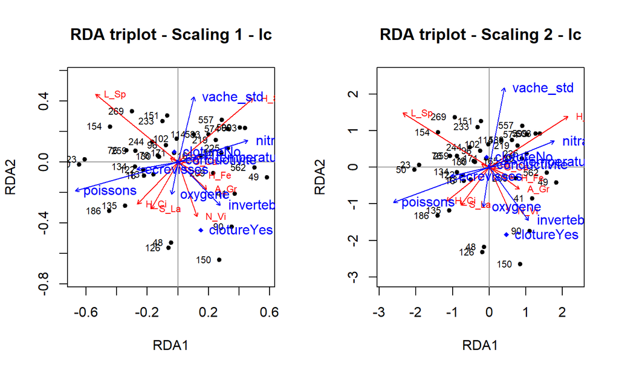

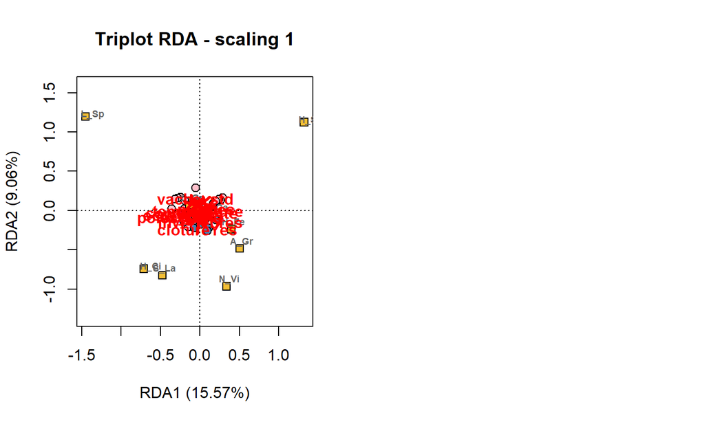

## Variance partitionning

```r
# Explanation of fraction labels (two, three and four explanatory matrices) with optional colours)
#par(mfrow = c(1, 3), mar = c(1, 1, 1, 1))
# showvarparts(2, bg = c("red", "blue"))
# showvarparts(3, bg = c("red", "blue", "yellow"))
# showvarparts(4, bg = c("red", "blue", "yellow", "green"))

## Variation partitioning with all explanatory variables
vache<-env[,1:2]
anim<-env[,7:9]
chem<-env[,3:6]
amphi.part.all <- varpart(amphi.hel, vache, chem, anim)
amphi.part.all
```

```
##
## Partition of variance in RDA
##
## Call: varpart(Y = amphi.hel, X = vache, chem, anim)
##
## Explanatory tables:
## X1:  vache
## X2:  chem
## X3:  anim
##
## No. of explanatory tables: 3
## Total variation (SS): 26.536
##             Variance: 0.71718
## No. of observations: 38
##
## Partition table:
##                       Df R.square Adj.R.square Testable
## [a+d+f+g] = X1         2  0.08248      0.03005     TRUE
## [b+d+e+g] = X2         4  0.13274      0.02762     TRUE
## [c+e+f+g] = X3         3  0.19505      0.12402     TRUE
## [a+b+d+e+f+g] = X1+X2  6  0.21458      0.06256     TRUE
## [a+c+d+e+f+g] = X1+X3  5  0.27099      0.15708     TRUE
## [b+c+d+e+f+g] = X2+X3  7  0.30922      0.14804     TRUE
## [a+b+c+d+e+f+g] = All  9  0.38340      0.18520     TRUE
## Individual fractions
## [a] = X1 | X2+X3       2               0.03717     TRUE
## [b] = X2 | X1+X3       4               0.02812     TRUE
## [c] = X3 | X1+X2       3               0.12264     TRUE
## [d]                    0              -0.00411    FALSE
## [e]                    0               0.00440    FALSE
## [f]                    0              -0.00222    FALSE
## [g]                    0              -0.00079    FALSE
## [h] = Residuals                        0.81480    FALSE
## Controlling 1 table X
## [a+d] = X1 | X3        2               0.03306     TRUE
## [a+f] = X1 | X2        2               0.03495     TRUE
## [b+d] = X2 | X3        4               0.02401     TRUE
## [b+e] = X2 | X1        4               0.03252     TRUE
## [c+e] = X3 | X1        3               0.12704     TRUE
## [c+f] = X3 | X2        3               0.12042     TRUE
## ---
## Use function 'rda' to test significance of fractions of interest
```

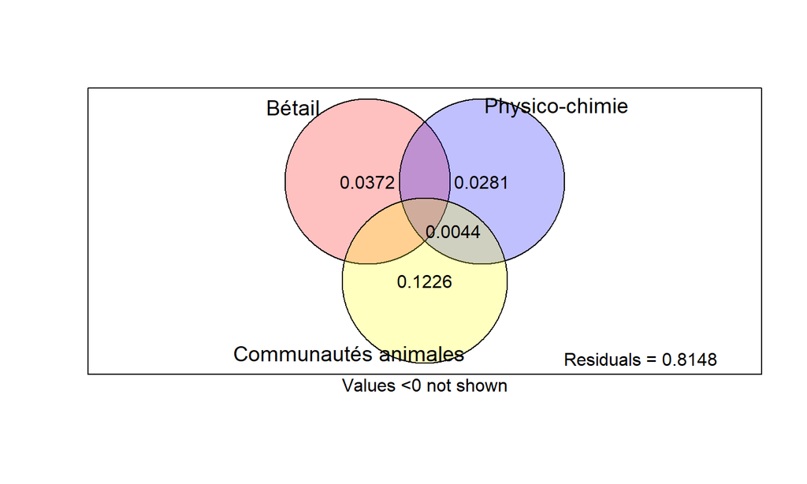

```r
par(mfrow= c(1,1))
plot(amphi.part.all, digits = 3, bg = c("red", "blue", "yellow"), Xnames = c("Bétail", "Physico-chimie", "Communautés animales"))
```

```r
cloture<-env[,1]
amphi.part <- varpart(amphi.hel, cloture, chem, anim)
amphi.part
```

```
##
## Partition of variance in RDA
##
## Call: varpart(Y = amphi.hel, X = cloture, chem, anim)
##
## Explanatory tables:
## X1:  cloture
## X2:  chem
## X3:  anim
##
## No. of explanatory tables: 3
## Total variation (SS): 26.536
##             Variance: 0.71718
## No. of observations: 38
##
## Partition table:
##                       Df R.square Adj.R.square Testable
## [a+d+f+g] = X1         1  0.06240      0.03636     TRUE
## [b+d+e+g] = X2         4  0.13274      0.02762     TRUE
## [c+e+f+g] = X3         3  0.19505      0.12402     TRUE
## [a+b+d+e+f+g] = X1+X2  5  0.20606      0.08200     TRUE
## [a+c+d+e+f+g] = X1+X3  4  0.25803      0.16810     TRUE
## [b+c+d+e+f+g] = X2+X3  7  0.30922      0.14804     TRUE
## [a+b+c+d+e+f+g] = All  8  0.37860      0.20718     TRUE
## Individual fractions
## [a] = X1 | X2+X3       1               0.05915     TRUE
## [b] = X2 | X1+X3       4               0.03909     TRUE
## [c] = X3 | X1+X2       3               0.12518     TRUE
## [d]                    0              -0.01507    FALSE
## [e]                    0               0.00656    FALSE
## [f]                    0              -0.00476    FALSE
## [g]                    0              -0.00296    FALSE
## [h] = Residuals                        0.79282    FALSE
## Controlling 1 table X
## [a+d] = X1 | X3        1               0.04407     TRUE
## [a+f] = X1 | X2        1               0.05439     TRUE
## [b+d] = X2 | X3        4               0.02401     TRUE
## [b+e] = X2 | X1        4               0.04565     TRUE
## [c+e] = X3 | X1        3               0.13174     TRUE
## [c+f] = X3 | X2        3               0.12042     TRUE
## ---
## Use function 'rda' to test significance of fractions of interest
```

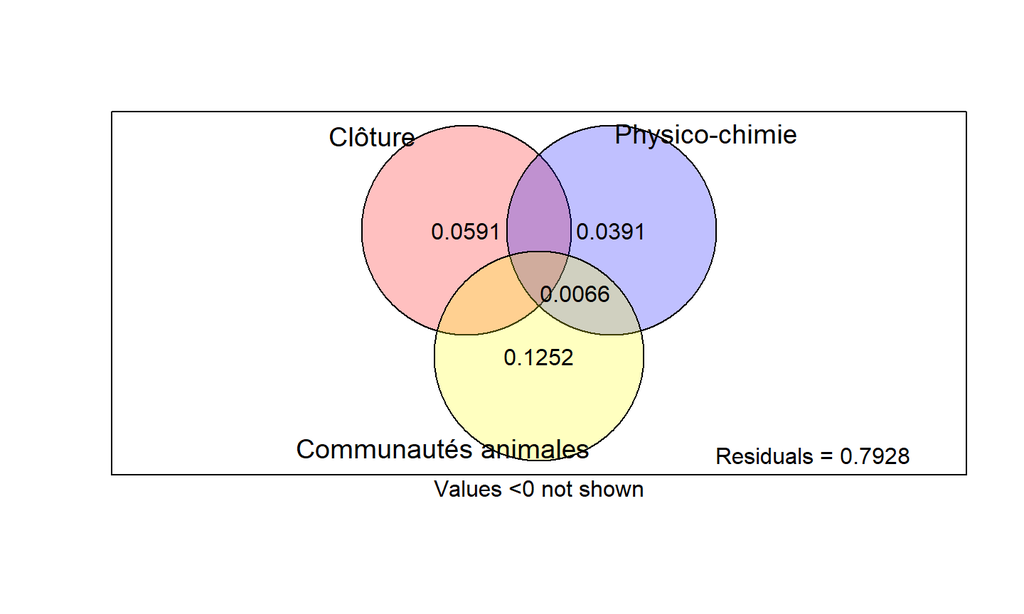

```r
plot(amphi.part, digits = 3, bg = c("red", "blue", "yellow"), Xnames = c("Clôture", "Physico-chimie", "Communautés animales")) #Étrangement, ça explique plus quand j'enlève vache_std
```

```r
nitrates=env$nitrates
poiss=env$poissons
amphi.part.select <- varpart(amphi.hel, cloture, nitrates, anim)
amphi.part.select
```

```
##
## Partition of variance in RDA
##
## Call: varpart(Y = amphi.hel, X = cloture, nitrates, anim)
##
## Explanatory tables:
## X1:  cloture
## X2:  nitrates
## X3:  anim
##
## No. of explanatory tables: 3
## Total variation (SS): 26.536
##             Variance: 0.71718
## No. of observations: 38
##
## Partition table:
##                       Df R.square Adj.R.square Testable
## [a+d+f+g] = X1         1  0.06240      0.03636     TRUE
## [b+d+e+g] = X2         1  0.05476      0.02851     TRUE
## [c+e+f+g] = X3         3  0.19505      0.12402     TRUE
## [a+b+d+e+f+g] = X1+X2  2  0.11937      0.06905     TRUE
## [a+c+d+e+f+g] = X1+X3  4  0.25803      0.16810     TRUE
## [b+c+d+e+f+g] = X2+X3  4  0.22318      0.12902     TRUE
## [a+b+c+d+e+f+g] = All  5  0.28465      0.17287     TRUE
## Individual fractions
## [a] = X1 | X2+X3       1               0.04385     TRUE
## [b] = X2 | X1+X3       1               0.00478     TRUE
## [c] = X3 | X1+X2       3               0.10383     TRUE
## [d]                    0               0.00022    FALSE
## [e]                    0               0.02791    FALSE
## [f]                    0              -0.00331    FALSE
## [g]                    0              -0.00441    FALSE
## [h] = Residuals                        0.82713    FALSE
## Controlling 1 table X
## [a+d] = X1 | X3        1               0.04407     TRUE
## [a+f] = X1 | X2        1               0.04054     TRUE
## [b+d] = X2 | X3        1               0.00500     TRUE
## [b+e] = X2 | X1        1               0.03269     TRUE
## [c+e] = X3 | X1        3               0.13174     TRUE
## [c+f] = X3 | X2        3               0.10052     TRUE
## ---
## Use function 'rda' to test significance of fractions of interest
```

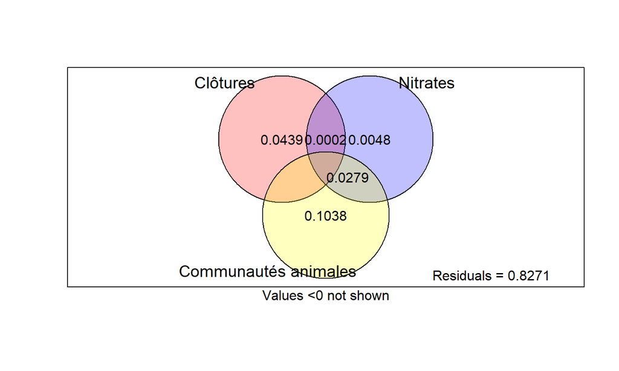

```r
par(mfrow= c(1,1))
plot(amphi.part.select, digits = 3, bg = c("red", "blue", "yellow"), Xnames = c("Clôtures", "Nitrates", "Communautés animales"))
```

```r
amphi.part.4 <- varpart(amphi.hel, cloture, nitrates, poiss)
amphi.part.4
```

```
##
## Partition of variance in RDA
##
## Call: varpart(Y = amphi.hel, X = cloture, nitrates, poiss)
##
## Explanatory tables:
## X1:  cloture
## X2:  nitrates
## X3:  poiss
##
## No. of explanatory tables: 3
## Total variation (SS): 26.536
##             Variance: 0.71718
## No. of observations: 38
##
## Partition table:
##                       Df R.square Adj.R.square Testable
## [a+d+f+g] = X1         1  0.06240      0.03636     TRUE
## [b+d+e+g] = X2         1  0.05476      0.02851     TRUE
## [c+e+f+g] = X3         1  0.13029      0.10613     TRUE
## [a+b+d+e+f+g] = X1+X2  2  0.11937      0.06905     TRUE
## [a+c+d+e+f+g] = X1+X3  2  0.19136      0.14515     TRUE
## [b+c+d+e+f+g] = X2+X3  2  0.15509      0.10681     TRUE
## [a+b+c+d+e+f+g] = All  3  0.22002      0.15120     TRUE
## Individual fractions
## [a] = X1 | X2+X3       1               0.04440     TRUE
## [b] = X2 | X1+X3       1               0.00605     TRUE
## [c] = X3 | X1+X2       1               0.08215     TRUE
## [d]                    0              -0.00538    FALSE
## [e]                    0               0.02664    FALSE
## [f]                    0              -0.00385    FALSE
## [g]                    0               0.00119    FALSE
## [h] = Residuals                        0.84880    FALSE
## Controlling 1 table X
## [a+d] = X1 | X3        1               0.03902     TRUE
## [a+f] = X1 | X2        1               0.04054     TRUE
## [b+d] = X2 | X3        1               0.00068     TRUE
## [b+e] = X2 | X1        1               0.03269     TRUE
## [c+e] = X3 | X1        1               0.10879     TRUE
## [c+f] = X3 | X2        1               0.07830     TRUE
## ---
## Use function 'rda' to test significance of fractions of interest
```

[figure not shown]

```r
par(mfrow= c(1,1))
plot(amphi.part.select, digits = 3, bg = c("red", "blue", "yellow"), Xnames = c("Clôtures", "Nitrates", "Poissons"))
```

```r
amphi.parsi <- varpart(amphi.hel, cloture, poiss)
amphi.parsi
```

```
##
## Partition of variance in RDA
##
## Call: varpart(Y = amphi.hel, X = cloture, poiss)
##
## Explanatory tables:
## X1:  cloture
## X2:  poiss
##
## No. of explanatory tables: 2
## Total variation (SS): 26.536
##             Variance: 0.71718
## No. of observations: 38
##
## Partition table:
##                      Df R.squared Adj.R.squared Testable
## [a+c] = X1            1   0.06240       0.03636     TRUE
## [b+c] = X2            1   0.13029       0.10613     TRUE
## [a+b+c] = X1+X2       2   0.19136       0.14515     TRUE
## Individual fractions
## [a] = X1|X2           1                 0.03902     TRUE
## [b] = X2|X1           1                 0.10879     TRUE
## [c]                   0                -0.00266    FALSE
## [d] = Residuals                         0.85485    FALSE
## ---
## Use function 'rda' to test significance of fractions of interest
```

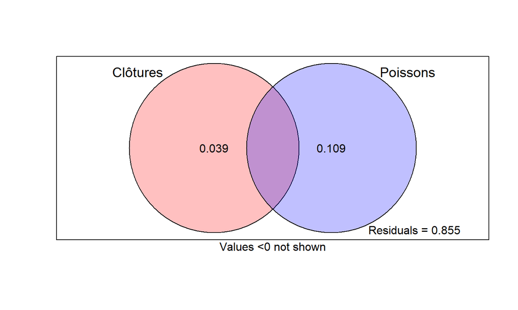

```r
par(mfrow= c(1,1))
plot(amphi.parsi, digits=2, bg = c("red", "blue"),Xnames = c("Clôtures",  "Poissons"))
```

## Matériel supplémentaire

### Effet de quelques variables moins discipliniés

Ensuite, on épargne le code un peu, pour des raisons visuelles, mais on a testé différentes transformation (plusieurs saveurs de log, et aussi la racine carré) sur la température, les poissons et les ecrevisses.  
- Visuellement, ce n’était pas très concluant. On a gardé la valeur de température sur son échelle originale. - Par contre, on a modélisé les poissons et écrevisses comme des valeurs binaires, question de vérifier si les conclusions varient beaucoup entre deux modèles globaux.

## Matériel supplémentaire

### RDA avec variables binaires

On lance la RDA partielle, avec des variables binaires poiur les poissons et les écrevisses. `env2` a été fait plus haut mais le code est caché.

```r
require(vegan)
(prda2=rda(amphi.hel ~ . + Condition(topo$aire +topo$profondeur), env2) )
```

```
## Call: rda(formula = amphi.hel ~ cloture + poiss_bin + ecre_bin +
## vache_std + conductivite + nitrates + oxygene + pH + invertebres +
## temperature + Condition(topo$aire + topo$profondeur), data = env2)
##
##               Inertia Proportion Rank
## Total         0.71718    1.00000
## Conditional   0.06892    0.09610    2
## Constrained   0.28294    0.39451    9
## Unconstrained 0.36532    0.50939    9
## Inertia is variance
##
## Eigenvalues for constrained axes:
##    RDA1    RDA2    RDA3    RDA4    RDA5    RDA6    RDA7    RDA8    RDA9
## 0.12609 0.06607 0.04414 0.02682 0.01433 0.00349 0.00156 0.00041 0.00004
##
## Eigenvalues for unconstrained axes:
##     PC1     PC2     PC3     PC4     PC5     PC6     PC7     PC8     PC9
## 0.09666 0.08897 0.06577 0.04402 0.02605 0.02371 0.01185 0.00439 0.00390
```

```r
 (R2adj_2 <- round(RsquareAdj(prda2)$adj.r.squared, dig=3))

anova(prda2, permutations = how(nperm = 999))
anova(prda2, by="axis", permutations = how(nperm = 999))
anova(prda2, by="term", permutations = how(nperm = 999))
vif.cca(prda2)

source("triplot.rda.R")

par(mfrow=c(1,2))

triplot.rda(prda2, scaling=1,
            move.origin=c(0, 0),
            mar.percent=0.05,
            silent=T)
triplot.rda(prda2, scaling=2,
            move.origin=c(0, 0),
            mar.percent=0.05,
            silent=T)
```

[output not shown]